# 7_IneractiveComputingJupyterNoteBook

## Section 9: Interactive Computing Using Jupyter Notebook

```
  Alem H Fitwi
  PhD Student (Privacy, Deep Learning, Networking (Edge Computing), IoD, Surveillance Systems)
  GA-Data Analyst
  Binghamton University-State University of New York
  December, 2017
```

### 9.1 Intriducing Data Science and Python

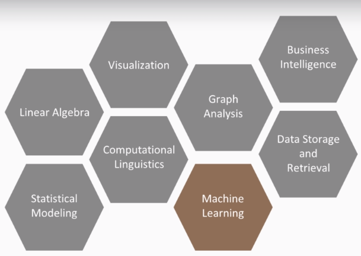

```python
from IPython.display import Image
from IPython.core.display import HTML
Image('ds_25.png')
```

Components of Data science

Python is the best tool for data science. The best programming lanaguage for data science career!

Python provides the following vital purposes and tools for data analysis:

```
completes the data scientist skill set
suitable for both development and production
handles small-to-large-scale data problems
easy to learn and grasp irrespective of your background
```

Python is:

```
general-purpose
Interpreted
OO with specilized packages
Allows to have uncountable and fast experimentations
```

Python offers a large, mature system of packages for data analysis and machine learning:

```
it integrates fifferent tools
it is very versatile
it is cross-platform
```

Python is faster compared to other mainstream data analysis lanaguages (R and Matlab)

It can work with large in-memory data

It is very simple to learn and use

New packages and improvements released are added frequently

In non-abatingly increasing development for it is used by many scientists

### 9.2 Enviroment preparation

1) Install Anaconda, a python cross-platform distribution from anaconda.com:

```
It includes 82 packages (Scikit-leanr, Numpy, Scipy, Pandas, Matplotlib,...)
Recent version of python
Jupyter
Spyder
JupyterLab
nltk
```

2) Download and install it:

```
Follow specific instructions on www.anaconda.com (for every platform)
Conda: an open source packagement mgt system (conda install ---)
       helpful for installing packages and for creating virtual environments
```

3) Commands:

```
 conda -V: for checking version (if available else error is reported)
 conda update conda:  for updating it to latest vrsion
 conda install package_name (example: conda install numpy)
```

### 9.3 Essential Packages

Analtical Packages:

```
Constitute a complete data science toolbox
Made up of extensively tested functions
Consist of higly optimized functions
Ready to achieve any scripting operation
```

Numpy

Offers a larger variety of scientific algorithms

Website - http://www.scipy.org/

Suggested install command - pip install scipy

COnventional import statement - import numpy as np

Handles all sorts of 1D and 2D arrays

Scipy

Offers a large variety of scientific algorithms:

```
Linear algebra
Sparse matrices
Signal and Image processing
Optimization and fast Fourier Transformation
```

website - http://www.scipy.org/

It also lends great power to the Numpy

Suggested install command -pip install scipy

Pandas

Offers DataFrames and Series (its specifc data structures)

Allows handling complex tables of data

one can perform numerous operations easily

website - http://pandas.pydata.org/

Suggested install command - pip install pandas

Conventional import statement - import pandas as pd

scikit-learn

Core of the data science operations on Python

Offers all that needed in terms of :

```
Data preprocessing
Supervised and Unsuprevised learning
Model Selection, validation, and error metrics
```

website - http://scikit-learn.org/

Suggested install command - pip install scikit-learn

Important module -sklearn

Matplotlib

A library containing building blocks to :

```
create quality plots from arrays
visualize them interactively
```

MATLAB-like plotting frameworks can be found inside the pyplot

website - http://matplotlib.org/

Suggested install command - pip install matplotlib

Conventional important statement - import matplotlib.pyplot as plt

Seaborn

Seaborn is a Python data visualization library based on matplotlib. It provides a high-level interface for drawing attractive and informative statistical graphics.

website - http://seaborn.pydata.org/

Suggested install command - pip install seaborn

Conventional important statement - import seaborn as sn

Additional

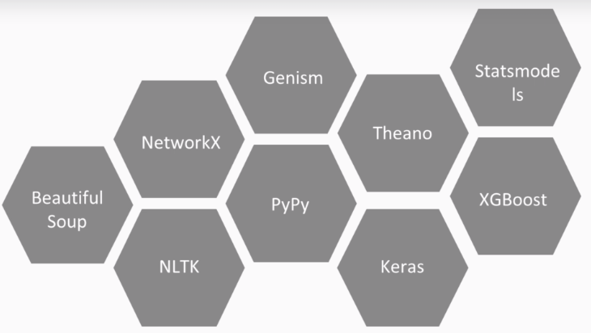

```python
from IPython.display import Image
from IPython.core.display import HTML
Image('ds_26.png')
```

### 9.4 Introducing the Jupyter Notebook

A tool for interactive tasks operable by:

```
a console
a web-based notebook
```

Offers special commands

Helps developers to better understand and build the code

One can easily combine:

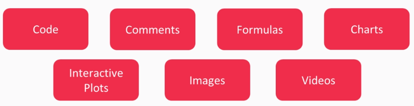

```python
from IPython.display import Image
from IPython.core.display import HTML
Image('ds_27.png')
```

Each jupyter Notebook can be made a complete scientific sketchpad.

Commands:

```
esc+M: Markdown
shift+enter: execute cell
object ?: gives details about object
    obj1=range(10)
    obj1? or obj1??
%time x=100 runs it 100 times
```

Feature: a characteristic property of the observation

Machine Learning uses it to establish models

Add features that can be interpreted as variables.

Use Latex sytanx for writing formulae

Using Double $ signs

$x=Ax+b$

Using Latex Syntax

\begin{align} Y=AX+B \end{align}

Using latex magic command in code Mode

```python
%%latex
\[
    |u(t)|=
    \begin{cases}
        u(t) & \text{if} t \geq 0 \\
        -u(t) & \text{otherwise}
    \end{cases}
\]
```

\[ |u(t)|= \begin{cases} u(t) & \text{if} t \geq 0 \\ -u(t) & \text{otherwise} \end{cases} \]

```python
%%latex
\[
    \begin{cases}
        f(x)&=(a+b)^2\\
            &=a^2+(a*b)+(a*b)+b^2\\
            &=a^2+2\cdot(a*b)+b^2\\
    \end{cases}
\]
```

\[ \begin{cases} f(x)&=(a+b)^2\\ &=a^2+(a*b)+(a*b)+b^2\\ &=a^2+2\cdot(a*b)+b^2\\ \end{cases} \]

Summation

$$Entropy=-\sum_{i=0}^n (p_{i}) log_{2}(p_{i})$$

Fraction

\begin{align} Precision &=\frac{TruePositive}{TruePositive\ +\ FalsePositive} \\ \end{align}

Square root

$$c = \sqrt{a^2 + b^2}$$

```python
from IPython.display import display, Math, Latex
display(Math(r'F(k) = \int_{-\infty}^{\infty} f(x) e^{2\pi i k} dx'))
```

$\displaystyle F(k) = \int_{-\infty}^{\infty} f(x) e^{2\pi i k} dx$

On Markdown

\begin{align} F(k) = \int_{-\infty}^{\infty} f(x) e^{2\pi i k} dx \end{align}

### 9.5 Scikit-learn Toy Datasets

Embedded in the scikit-learn packages

Can be directly loaded into Python by the import command

don't require dowload from any external internet repository

Examples: Iris, Boston, and Digital Datasets

https://scikit-learn.org/stable/datasets/index.html

Advantages of using such datasets:

```
Very easy to load, handle, and explore
Has low dimensionality
Modeling activities take almost no time on any computer
Relationship are well known
Task is challenging, but it is not very arduous
```

Iris Datset

Four columns:sepal length (cm)', 'sepal width (cm)', 'petal length (cm)', 'petal width (cm)'

```python
from sklearn import datasets
dat=datasets.load_iris()
dat.feature_names
```

```
['sepal length (cm)',
 'sepal width (cm)',
 'petal length (cm)',
 'petal width (cm)']
```

```python
dat.target
```

```
array([0, 0, 0, 0, 0, 0, 0, 0, 0, 0, 0, 0, 0, 0, 0, 0, 0, 0, 0, 0, 0, 0,
       0, 0, 0, 0, 0, 0, 0, 0, 0, 0, 0, 0, 0, 0, 0, 0, 0, 0, 0, 0, 0, 0,
       0, 0, 0, 0, 0, 0, 1, 1, 1, 1, 1, 1, 1, 1, 1, 1, 1, 1, 1, 1, 1, 1,
       1, 1, 1, 1, 1, 1, 1, 1, 1, 1, 1, 1, 1, 1, 1, 1, 1, 1, 1, 1, 1, 1,
       1, 1, 1, 1, 1, 1, 1, 1, 1, 1, 1, 1, 2, 2, 2, 2, 2, 2, 2, 2, 2, 2,
       2, 2, 2, 2, 2, 2, 2, 2, 2, 2, 2, 2, 2, 2, 2, 2, 2, 2, 2, 2, 2, 2,
       2, 2, 2, 2, 2, 2, 2, 2, 2, 2, 2, 2, 2, 2, 2, 2, 2, 2])
```

```python
len(dat.target)
```

```
150
```

```python
dat.data.shape
```

```
(150, 4)
```

```python
import pandas as pd
df=pd.DataFrame(dat.data,columns=dat.feature_names)
```

```python
df['target']=dat.target
df1=df
```

```python
df.head(5)
```

|  | sepal length (cm) | sepal width (cm) | petal length (cm) | petal width (cm) | target |
| --- | --- | --- | --- | --- | --- |
| 0 | 5.1 | 3.5 | 1.4 | 0.2 | 0 |
| 1 | 4.9 | 3.0 | 1.4 | 0.2 | 0 |
| 2 | 4.7 | 3.2 | 1.3 | 0.2 | 0 |
| 3 | 4.6 | 3.1 | 1.5 | 0.2 | 0 |
| 4 | 5.0 | 3.6 | 1.4 | 0.2 | 0 |

```python
# Adding the color types
```

```python
# Using a function coupled iwth apply
def addColor(x):
    if x==0:
        return "red"
    elif x==1:
        return "green"
    else:
        return "blue"
```

```python
df['color']=df['target'].apply(addColor)
```

```python
df.head()
```

|  | sepal length (cm) | sepal width (cm) | petal length (cm) | petal width (cm) | target | color |
| --- | --- | --- | --- | --- | --- | --- |
| 0 | 5.1 | 3.5 | 1.4 | 0.2 | 0 | red |
| 1 | 4.9 | 3.0 | 1.4 | 0.2 | 0 | red |
| 2 | 4.7 | 3.2 | 1.3 | 0.2 | 0 | red |
| 3 | 4.6 | 3.1 | 1.5 | 0.2 | 0 | red |
| 4 | 5.0 | 3.6 | 1.4 | 0.2 | 0 | red |

```python
# Using function, lambda, and apply
df2=df1
df2['color']=df2['target'].apply(lambda x: addColor(x))
```

```python
df2.tail(3)
```

|  | sepal length (cm) | sepal width (cm) | petal length (cm) | petal width (cm) | target | color |
| --- | --- | --- | --- | --- | --- | --- |
| 147 | 6.5 | 3.0 | 5.2 | 2.0 | 2 | blue |
| 148 | 6.2 | 3.4 | 5.4 | 2.3 | 2 | blue |
| 149 | 5.9 | 3.0 | 5.1 | 1.8 | 2 | blue |

```python
# Using lambda and apply only
df1['color']=df1['target'].apply(lambda x:"red" if x==0 else ("green" if x==1 else "blue"))
```

```python
df1.tail(4)
```

|  | sepal length (cm) | sepal width (cm) | petal length (cm) | petal width (cm) | target | color |
| --- | --- | --- | --- | --- | --- | --- |
| 146 | 6.3 | 2.5 | 5.0 | 1.9 | 2 | blue |
| 147 | 6.5 | 3.0 | 5.2 | 2.0 | 2 | blue |
| 148 | 6.2 | 3.4 | 5.4 | 2.3 | 2 | blue |
| 149 | 5.9 | 3.0 | 5.1 | 1.8 | 2 | blue |

```python
df1.to_csv('iris.csv')
```

Scatter plot matrix

[figure not shown]

```python
from IPython.display import Image
from IPython.core.display import HTML
Image('ds_28.png')
```

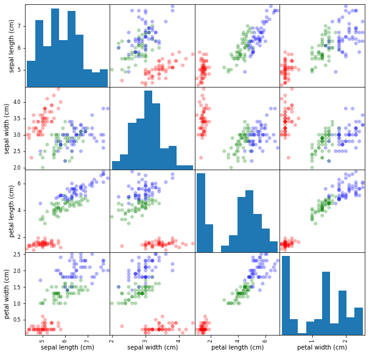

```python
import pandas as pd
import numpy as np
colors = list()
palette = {0:"red",1:"green",2:"blue"}
for c in np.nditer(dat.target):
    colors.append(palette[int(c)])
dataframe = pd.DataFrame(dat.data, columns=dat.feature_names)

sc = pd.plotting.scatter_matrix(dataframe,alpha=0.3, figsize=(10,10),
    diagonal='hist', color=colors, marker='o', grid=True)
```

The MLdata.org Public Repositorry

can be downloanded directly from:

```
Machine Learning dataset repository
LIBSVM data website
```

Access to the Internet is needed

mldata.org is public data repository funded by the European Union

```python
from sklearn.datasets import fetch_mldata
```

The LIBSVM Data Examples

Interesting repository with data in SVM format

http://www.csie.ntu.edu.tw/~cjlin/libsvmtools/datasets/binary/a1a

```python
import urllib
target_page='http://www.csie.ntu.edu.tw/~cjlin/libsvmtools/datasets/binary/a1a'
a2a = urllib.request.urlopen(target_page)
```

```python
from sklearn.datasets import load_svmlight_file
x_train,y_train=load_svmlight_file(a2a)
print(f"The shape of x_train is {x_train.shape} and that of y_train is {y_train.shape}")
```

```
The shape of x_train is (1605, 119) and that of y_train is (1605,)
```

Download it and load it to the program

```python
# Only number types can be loaded using np.loadtxt
housing=np.loadtxt('1M.csv', delimiter=',')
```

```python
cols=["col1","col2","col3","col4","col5","col6","col7","col8","col9","col10"]
```

```python
housing.shape
```

```
(1000000, 10)
```

Mixed types of variables can be addressed by:

```
pandas.read_table
pandas.read_csv
```

Data extracted by the values method

dtype is an important default parameter

This is set to float

Loadtxt converts loaded data into floating-point number

```python
# Convert numeric data to int using astype
housing_int=housing.astype(int)
```

```python
housing [0,:3]
```

```
array([10., 12., 20.])
```

```python
housing_int [0,:3]
```

```
array([10, 12, 20])
```

pandas library offers the solution to this

DataFrame easily handles datasets in a matrix form made up of different types of variables

```python
df=pd.read_csv('1M.csv', header=None)
```

```python
df.head()
```

|  | 0 | 1 | 2 | 3 | 4 | 5 | 6 | 7 | 8 | 9 |
| --- | --- | --- | --- | --- | --- | --- | --- | --- | --- | --- |
| 0 | 10 | 12 | 20 | 18 | 6 | 14 | 12 | 17 | 14 | 9 |
| 1 | 8 | 19 | 1 | 17 | 10 | 7 | 19 | 8 | 16 | 11 |
| 2 | 8 | 19 | 5 | 11 | 4 | 12 | 9 | 20 | 17 | 2 |
| 3 | 7 | 12 | 7 | 19 | 8 | 1 | 12 | 17 | 1 | 18 |
| 4 | 3 | 15 | 10 | 15 | 3 | 5 | 5 | 20 | 2 | 11 |

```python
df.columns=cols
```

```python
df.head()
```

|  | col1 | col2 | col3 | col4 | col5 | col6 | col7 | col8 | col9 | col10 |
| --- | --- | --- | --- | --- | --- | --- | --- | --- | --- | --- |
| 0 | 10 | 12 | 20 | 18 | 6 | 14 | 12 | 17 | 14 | 9 |
| 1 | 8 | 19 | 1 | 17 | 10 | 7 | 19 | 8 | 16 | 11 |
| 2 | 8 | 19 | 5 | 11 | 4 | 12 | 9 | 20 | 17 | 2 |
| 3 | 7 | 12 | 7 | 19 | 8 | 1 | 12 | 17 | 1 | 18 |
| 4 | 3 | 15 | 10 | 15 | 3 | 5 | 5 | 20 | 2 | 11 |

```python
%timeit df=pd.read_csv('1M.csv', header=None)
```

```
710 ms ± 37.2 ms per loop (mean ± std. dev. of 7 runs, 1 loop each)
```

```python
df.info()
```

```
<class 'pandas.core.frame.DataFrame'>
RangeIndex: 1000000 entries, 0 to 999999
Data columns (total 10 columns):
col1     1000000 non-null int64
col2     1000000 non-null int64
col3     1000000 non-null int64
col4     1000000 non-null int64
col5     1000000 non-null int64
col6     1000000 non-null int64
col7     1000000 non-null int64
col8     1000000 non-null int64
col9     1000000 non-null int64
col10    1000000 non-null int64
dtypes: int64(10)
memory usage: 76.3 MB
```

```python
nan=df[pd.DataFrame.isna(df)==False]
```

```python
# Checking if there is any missing value

# Counting the missing values in each column
df.isna().sum()
```

```
col1     0
col2     0
col3     0
col4     0
col5     0
col6     0
col7     0
col8     0
col9     0
col10    0
dtype: int64
```

```python
df.isnull().sum()
```

```
col1     0
col2     0
col3     0
col4     0
col5     0
col6     0
col7     0
col8     0
col9     0
col10    0
dtype: int64
```

```python
#Check in any value is missing in the dataframe
df.isnull().values.any()
```

```
False
```

```python
df.isna().values.any()
```

```
False
```